# High School and Beyond survey Classification Problem

Two hundred observations were randomly sampled from the High School and Beyond survey, a survey conducted on high school seniors by the National Center of Education Statistics.

## Introduction

Before we get started, it is important for us to install the necessary R packages into R and launch these R packages into R environment. A data frame with 200 observations and 11 variables.

```r
packages = c('blorr','mlbench')
for (p in packages){
  if(!require(p, character.only = T)){
    install.packages(p)
  }
  library(p,character.only = T)
}
```

## Blorr for Classification

The blorr package offers tools for building and validating binary logistic regression models. It is most suitable for beginner/intermediate R users and those who teach statistics using R. The API is very simple and most of the functions take either a data.frame/tibble or a model as input. blorr use consistent prefix blr_ for easy tab completion.

Let us begin with careful bivariate analysis of each possible variable and the outcome variable. We will use information value and likelihood ratio chi square test for selecting the initial set of predictors for our model. The bivariate analysis is currently avialable for categorical predictors only.

```r
blr_bivariate_analysis(hsb2, honcomp, female, prog, race, schtyp)
```

```
##                          Bivariate Analysis
## ---------------------------------------------------------------------
## Variable    Information Value    LR Chi Square    LR DF    LR p-value
## ---------------------------------------------------------------------
##  female           0.10              3.9350          1        0.0473
##   prog            0.43              16.1450         2        3e-04
##   race            0.33              11.3694         3        0.0099
##  schtyp           0.00              0.0445          1        0.8330
## ---------------------------------------------------------------------
```

Weight of evidence (WoE) is used to assess the relative risk of di¤erent attributes for a characteristic and as a means to transform characteristics into variables. It is also a very useful tool for binning. The WoE for any group with average odds is zero. A negative WoE indicates that the proportion of defaults is higher for that attribute than the overall proportion and indicates higher risk.

The information value is used to rank order variables in terms of their predictive power. A high information value indicates a high ability to discriminate. Values for the information value will always be positive and may be above 3 when assessing highly predictive characteristics. Characteristics with information values less than 0:10 are typically viewed as weak, while values over 0.30 are sought after.

```r
blr_bivariate_analysis(hsb2, female, prog)
```

```
##                          Bivariate Analysis
## ---------------------------------------------------------------------
## Variable    Information Value    LR Chi Square    LR DF    LR p-value
## ---------------------------------------------------------------------
##   prog            0.00              0.0528          2        0.9739
## ---------------------------------------------------------------------
```

## Plot

[figure not shown]

```r
k <- blr_woe_iv(hsb2, honcomp, female)
plot(k)
```

## Multiple Variables

We can generate the weight of evidence and information value for multiple variables using blr_woe_iv_stats().

```r
blr_woe_iv_stats(hsb2, honcomp, female)
```

```
## Variable: female
##
##                            Weight of Evidence
## -------------------------------------------------------------------------
## levels    count_0s    count_1s    dist_0s    dist_1s        woe      iv
## -------------------------------------------------------------------------
##   0          73          18          0.50       0.34       0.38     0.06
##   1          74          35          0.50       0.66      -0.27     0.04
## -------------------------------------------------------------------------
##
##       Information Value
## -----------------------------
## Variable    Information Value
## -----------------------------
##  female          0.1023
## -----------------------------
```

```r
blr_woe_iv_stats(hsb2, honcomp, female)
```

```
## Variable: female
##
##                            Weight of Evidence
## -------------------------------------------------------------------------
## levels    count_0s    count_1s    dist_0s    dist_1s        woe      iv
## -------------------------------------------------------------------------
##   0          73          18          0.50       0.34       0.38     0.06
##   1          74          35          0.50       0.66      -0.27     0.04
## -------------------------------------------------------------------------
##
##       Information Value
## -----------------------------
## Variable    Information Value
## -----------------------------
##  female          0.1023
## -----------------------------
```

blr_woe_iv() and blr_woe_iv_stats() are currently avialable for categorical predictors only.

## Stepwise Selection

For the initial/ first cut model, all the independent variables are put into the model. Our goal is to include a limited number of independent variables (5-15) which are all significant, without sacrificing too much on the model performance. The rationale behind not-including too many variables is that the model would be over fitted and would become unstable when tested on the validation sample. The variable reduction is done using forward or backward or stepwise variable selection procedures. We will use blr_step_aic_both() to shortlist predictors for our model.

### Model

```r
model <- glm(prog ~ .,data = hsb2, family = binomial(link = 'logit'))
```

### Selection Summary

```r
blr_step_aic_both(model)
```

```
## Stepwise Selection Method
## -------------------------
##
## Candidate Terms:
##
## 1 . id
## 2 . female
## 3 . race
## 4 . ses
## 5 . schtyp
## 6 . read
## 7 . write
## 8 . math
## 9 . science
## 10 . socst
## 11 . honcomp
##
##
## Variables Entered/Removed:
##
## - math added
## - science added
## - ses added
## - read added
##
## No more variables to be added or removed.
```

```
##
##
##                     Stepwise Summary
## ------------------------------------------------------
## Variable     Method       AIC        BIC      Deviance
## ------------------------------------------------------
## math        addition    212.547    219.144     208.547
## science     addition    209.197    219.091     203.197
## ses         addition    208.372    224.863     198.372
## read        addition    208.295    228.085     196.295
## ------------------------------------------------------
```

### Plot

```r
k <- blr_step_aic_both(model)
```

```
## Stepwise Selection Method
## -------------------------
##
## Candidate Terms:
##
## 1 . id
## 2 . female
## 3 . race
## 4 . ses
## 5 . schtyp
## 6 . read
## 7 . write
## 8 . math
## 9 . science
## 10 . socst
## 11 . honcomp
##
##
## Variables Entered/Removed:
##
## - math added
## - science added
## - ses added
## - read added
##
## No more variables to be added or removed.
```

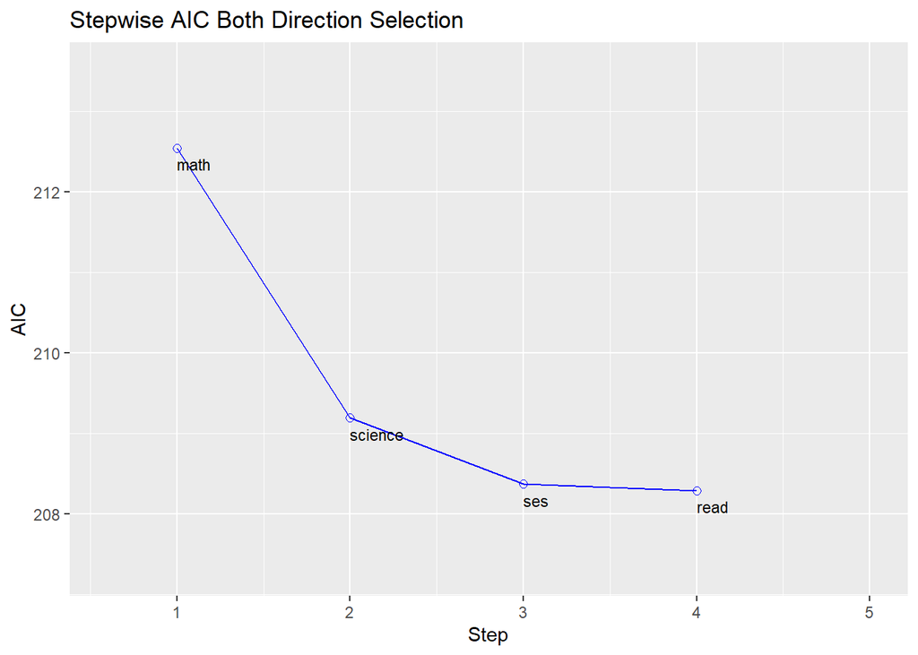

```r
plot(k)
```

# Regression Output

## Model

We can use bivariate analysis and stepwise selection procedure to shortlist predictors and build the model using the glm(). The predictors used in the below model are for illustration purposes and not necessarily shortlisted from the bivariate analysis and variable selection procedures.

```r
model <- glm(prog ~ honcomp + female+race,data = hsb2, family = binomial(link = 'logit'))
```

Use blr_regress() to generate comprehensive regression output. It accepts either of the following

- model built using glm()
- model formula and data

### Using the model

Let us look at the output generated from blr_regress():

```r
blr_regress(model)
```

```
##                              Model Overview
## ------------------------------------------------------------------------
## Data Set    Resp Var    Obs.    Df. Model    Df. Residual    Convergence
## ------------------------------------------------------------------------
##   data        prog      200        199           194            TRUE
## ------------------------------------------------------------------------
##
##                     Response Summary
## --------------------------------------------------------
## Outcome        Frequency        Outcome        Frequency
## --------------------------------------------------------
##    0              45               1              105
## --------------------------------------------------------
##
##                   Maximum Likelihood Estimates
## -----------------------------------------------------------------
##  Parameter     DF    Estimate    Std. Error    z value    Pr(>|z|)
## -----------------------------------------------------------------
## (Intercept)    1      1.5394        0.5714     2.6942      0.0071
##  honcomp1      1      0.9444        0.4634     2.0377      0.0416
##   female1      1      0.0262        0.3505     0.0748      0.9403
##    race2       1     -1.3968        0.8638    -1.6169      0.1059
##    race3       1     -0.5316        0.7582    -0.7011      0.4832
##    race4       1     -0.5254        0.5897    -0.8910      0.3730
## -----------------------------------------------------------------
##
##  Association of Predicted Probabilities and Observed Responses
## ----------------------------------------------------------------
## % Concordant          0.5366          Somers' D         0.2891
## % Discordant          0.2959          Gamma             0.2407
## % Tied                0.1675          Tau-a             0.0844
## Pairs                  6975           c                 0.6204
## ----------------------------------------------------------------
```

If you want to examine the odds ratio estimates, set odd_conf_limit to TRUE. The odds ratio estimates are not explicitly computed as we observed considerable increase in computation time when dealing with large data sets.

### Using Formula

Let us use the model formula and the data set to generate the above results.

```r
blr_regress(prog ~ honcomp + female+race,data = hsb2, family = binomial(link = 'logit'))
```

```
##                              Model Overview
## ------------------------------------------------------------------------
## Data Set    Resp Var    Obs.    Df. Model    Df. Residual    Convergence
## ------------------------------------------------------------------------
##   data        prog      200        199           194            TRUE
## ------------------------------------------------------------------------
##
##                     Response Summary
## --------------------------------------------------------
## Outcome        Frequency        Outcome        Frequency
## --------------------------------------------------------
##    0              45               1              105
## --------------------------------------------------------
##
##                   Maximum Likelihood Estimates
## -----------------------------------------------------------------
##  Parameter     DF    Estimate    Std. Error    z value    Pr(>|z|)
## -----------------------------------------------------------------
## (Intercept)    1      1.5394        0.5714     2.6942      0.0071
##  honcomp1      1      0.9444        0.4634     2.0377      0.0416
##   female1      1      0.0262        0.3505     0.0748      0.9403
##    race2       1     -1.3968        0.8638    -1.6169      0.1059
##    race3       1     -0.5316        0.7582    -0.7011      0.4832
##    race4       1     -0.5254        0.5897    -0.8910      0.3730
## -----------------------------------------------------------------
##
##  Association of Predicted Probabilities and Observed Responses
## ----------------------------------------------------------------
## % Concordant          0.5366          Somers' D         0.2891
## % Discordant          0.2959          Gamma             0.2407
## % Tied                0.1675          Tau-a             0.0844
## Pairs                  6975           c                 0.6204
## ----------------------------------------------------------------
```

# Model Fit Statistics

Model fit statistics are available to assess how well the model fits the data and to compare two different models.The output includes likelihood ratio test, AIC, BIC and a host of pseudo r-squared measures. You can read more about pseudo r-squared at https://stats.idre.ucla.edu/other/mult-pkg/faq/general/faq-what-are-pseudo-r-squareds/.

## Single Model

```r
blr_model_fit_stats(model)
```

```
##                                Model Fit Statistics
## -----------------------------------------------------------------------------------
## Log-Lik Intercept Only:      -106.633    Log-Lik Full Model:               -103.389
## Deviance(194):                206.779    LR(5):                               6.487
##                                          Prob > LR:                           0.262
## MCFadden's R2                   0.030    McFadden's Adj R2:                  -0.026
## ML (Cox-Snell) R2:              0.032    Cragg-Uhler(Nagelkerke) R2:          0.049
## McKelvey & Zavoina's R2:        0.060    Efron's R2:                          0.036
## Count R2:                       0.775    Adj Count R2:                        0.000
## BIC:                          238.569    AIC:                               218.779
## -----------------------------------------------------------------------------------
```

# Model Validation

# Hosmer Lemeshow Test

Hosmer and Lemeshow developed a goodness-of-fit test for logistic regression models with binary responses. The test involves dividing the data into approximately ten groups of roughly equal size based on the percentiles of the estimated probabilities. The observations are sorted in increasing order of their estimated probability of having an even outcome. The discrepancies between the observed and expected number of observations in these groups are summarized by the Pearson chi-square statistic, which is then compared to chi-square distribution with t degrees of freedom, where t is the number of groups minus 2. Lower values of Goodness-of-fit are preferred.

```r
blr_test_hosmer_lemeshow(model)
```

```
##            Partition for the Hosmer & Lemeshow Test
## --------------------------------------------------------------
##                         def = 1                 def = 0
## Group    Total    Observed    Expected    Observed    Expected
## --------------------------------------------------------------
##   1       66         45        47.27         21        18.73
##   4       59         46        43.58         13        15.42
##   7       17         16        13.63         1          3.37
##   8       25         20        21.42         5          3.58
##   9       31         26        27.25         5          3.75
##  10        2         2          1.85         0          0.15
##  NA       NA         NA          NA          NA          NA
##  NA       NA         NA          NA          NA          NA
##  NA       NA         NA          NA          NA          NA
##  NA       NA         NA          NA          NA          NA
## --------------------------------------------------------------
##
##      Goodness of Fit Test
## ------------------------------
## Chi-Square    DF    Pr > ChiSq
## ------------------------------
##   4.2648      8       0.8325
## ------------------------------
```

# Gains Table & Lift Chart

A lift curve is a graphical representation of the % of cumulative events captured at a specific cut-off. The cut-off can be a particular decile or a percentile. Similar, to rank ordering procedure, the data is in descending order of the scores and is then grouped into deciles/percentiles. The cumulative number of observations and events are then computed for each decile/percentile. The lift curve is the created using the cumulative % population as the x-axis and the cumulative percentage of events as the y-axis.

```r
blr_gains_table(model)
```

```
##    decile total  1  0        ks  tp tn fp fn sensitivity specificity accuracy
## 1       1    20 16  4 11.027569  16 91  4 89    15.23810    95.78947     53.5
## 2       2    20 14  6 18.045113  30 85 10 75    28.57143    89.47368     57.5
## 3       3    20 12  8 21.052632  42 77 18 63    40.00000    81.05263     59.5
## 4       4    20  9 11 18.045113  51 66 29 54    48.57143    69.47368     58.5
## 5       5    20 11  9 19.047619  62 57 38 43    59.04762    60.00000     59.5
## 6       6    20  9 11 16.040100  71 46 49 34    67.61905    48.42105     58.5
## 7       7    20  7 13  9.022556  78 33 62 27    74.28571    34.73684     55.5
## 8       8    20 10 10  8.020050  88 23 72 17    83.80952    24.21053     55.5
## 9       9    20  9 11  5.012531  97 12 83  8    92.38095    12.63158     54.5
## 10     10    20  8 12  0.000000 105  0 95  0   100.00000     0.00000     52.5
```

### Lift Chart

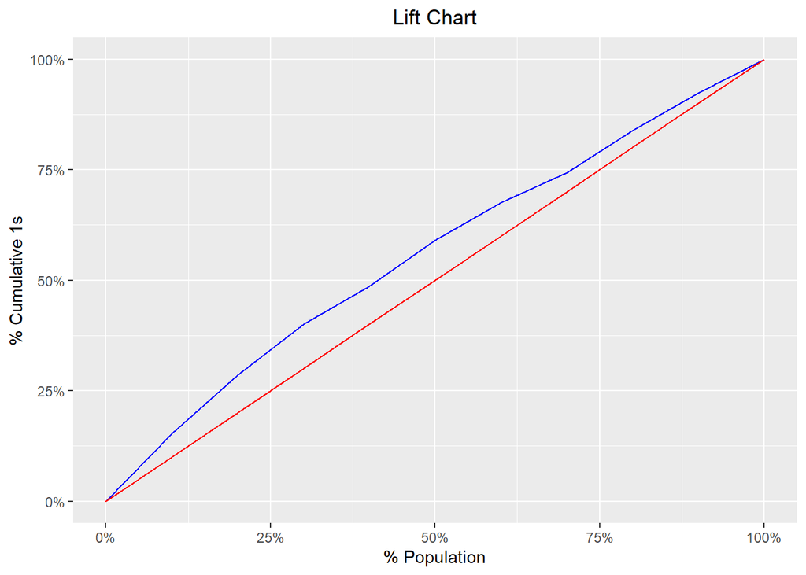

```r
y <- blr_gains_table(model)
plot(y)
```